# Прогноз оттока клиентов

Заказчик, оператор связи, хочет научиться прогнозировать отток клиентов. Если выяснится, что пользователь планирует уйти, ему будут предложены промокоды и специальные условия. Команда оператора собрала персональные данные о некоторых клиентах, информацию об их тарифах и договорах.

Так как мы решаем задачу бинарной классификации, в которой будет наблюдаться дисбаланс классов, воспользуемся метрикой AUC-ROC для поиска лучшей модели (пороговое значение на тестовой выборке должно быть не меньше 0.85).

Цель проекта состоит в построении модели, ищущей клиентов, собирающихся уйти.

## Исследовательский анализ данных

### Загрузка данных

```python
!pip install phik -q
!pip install imblearn -q
!pip install shap -q
```

```python
import time

import lightgbm as lgb
import matplotlib.pyplot as plt
import numpy as np
import pandas as pd
import seaborn as sns
import phik

from imblearn.over_sampling import RandomOverSampler
from imblearn.pipeline import Pipeline
from sklearn.compose import ColumnTransformer
from sklearn.dummy import DummyClassifier
from sklearn.ensemble import RandomForestClassifier
from sklearn.linear_model import LogisticRegression
from sklearn.metrics import (
    roc_auc_score,
    accuracy_score,
    confusion_matrix,
    RocCurveDisplay,
    roc_curve,
)
from sklearn.model_selection import (
    train_test_split,
    StratifiedKFold,
    GridSearchCV,
)
from sklearn.preprocessing import OneHotEncoder, StandardScaler
```

```python
df_contract = pd.read_csv('/datasets/contract_new.csv')
df_internet = pd.read_csv('/datasets/internet_new.csv')
df_personal = pd.read_csv('/datasets/personal_new.csv')
df_phone = pd.read_csv('/datasets/phone_new.csv')
```

### Датасет "Контракты"

#### Предобработка данных

```python
df_contract.head()
```

|  | customerID | BeginDate | EndDate | Type | PaperlessBilling | PaymentMethod | MonthlyCharges | TotalCharges |
| --- | --- | --- | --- | --- | --- | --- | --- | --- |
| 0 | 7590-VHVEG | 2020-01-01 | No | Month-to-month | Yes | Electronic check | 29.85 | 31.04 |
| 1 | 5575-GNVDE | 2017-04-01 | No | One year | No | Mailed check | 56.95 | 2071.84 |
| 2 | 3668-QPYBK | 2019-10-01 | No | Month-to-month | Yes | Mailed check | 53.85 | 226.17 |
| 3 | 7795-CFOCW | 2016-05-01 | No | One year | No | Bank transfer (automatic) | 42.30 | 1960.6 |
| 4 | 9237-HQITU | 2019-09-01 | No | Month-to-month | Yes | Electronic check | 70.70 | 353.5 |

```python
df_contract.info()
```

```
<class 'pandas.core.frame.DataFrame'>
RangeIndex: 7043 entries, 0 to 7042
Data columns (total 8 columns):
 #   Column            Non-Null Count  Dtype
---  ------            --------------  -----
 0   customerID        7043 non-null   object
 1   BeginDate         7043 non-null   object
 2   EndDate           7043 non-null   object
 3   Type              7043 non-null   object
 4   PaperlessBilling  7043 non-null   object
 5   PaymentMethod     7043 non-null   object
 6   MonthlyCharges    7043 non-null   float64
 7   TotalCharges      7043 non-null   object
dtypes: float64(1), object(7)
memory usage: 440.3+ KB
```

Пропуски отсутствуют, приведём столбцы к нужному типу данных.

```python
df_contract['BeginDate'] = pd.to_datetime(df_contract['BeginDate'])
```

```python
df_contract['EndDate'] = pd.to_datetime(df_contract['EndDate'], errors='coerce')
```

Так как большинство клиентов не ушло из компании (в EndTime было указано "No"), при изменении типа данных мы заменили эти значения на эквивалент NaN - NaT (Not a Time).

```python
df_contract[df_contract['TotalCharges'] == ' ']
```

|  | customerID | BeginDate | EndDate | Type | PaperlessBilling | PaymentMethod | MonthlyCharges | TotalCharges |
| --- | --- | --- | --- | --- | --- | --- | --- | --- |
| 488 | 4472-LVYGI | 2020-02-01 | NaT | Two year | Yes | Bank transfer (automatic) | 52.55 |  |
| 753 | 3115-CZMZD | 2020-02-01 | NaT | Two year | No | Mailed check | 20.25 |  |
| 936 | 5709-LVOEQ | 2020-02-01 | NaT | Two year | No | Mailed check | 80.85 |  |
| 1082 | 4367-NUYAO | 2020-02-01 | NaT | Two year | No | Mailed check | 25.75 |  |
| 1340 | 1371-DWPAZ | 2020-02-01 | NaT | Two year | No | Credit card (automatic) | 56.05 |  |
| 3331 | 7644-OMVMY | 2020-02-01 | NaT | Two year | No | Mailed check | 19.85 |  |
| 3826 | 3213-VVOLG | 2020-02-01 | NaT | Two year | No | Mailed check | 25.35 |  |
| 4380 | 2520-SGTTA | 2020-02-01 | NaT | Two year | No | Mailed check | 20.00 |  |
| 5218 | 2923-ARZLG | 2020-02-01 | NaT | One year | Yes | Mailed check | 19.70 |  |
| 6670 | 4075-WKNIU | 2020-02-01 | NaT | Two year | No | Mailed check | 73.35 |  |
| 6754 | 2775-SEFEE | 2020-02-01 | NaT | Two year | Yes | Bank transfer (automatic) | 61.90 |  |

```python
df_contract.loc[df_contract['TotalCharges'] == ' ', 'TotalCharges'] = df_contract['MonthlyCharges']
```

```python
df_contract['TotalCharges'] = df_contract['TotalCharges'].astype('float64')
```

```python
df_contract.describe()
```

|  | MonthlyCharges | TotalCharges |
| --- | --- | --- |
| count | 7043.000000 | 7043.000000 |
| mean | 64.761692 | 2115.377573 |
| std | 30.090047 | 2112.678861 |
| min | 18.250000 | 19.050000 |
| 25% | 35.500000 | 436.750000 |
| 50% | 70.350000 | 1343.350000 |
| 75% | 89.850000 | 3236.690000 |
| max | 118.750000 | 9221.380000 |

В числовых значениях аномалий не наблюдается. Проверим ID клиентов на наличие дупликатов.

```python
df_contract['customerID'].duplicated().sum()
```

```
0
```

Дупликатов нет. Теперь проверим данные на опечатки.

```python
for col in df_contract.drop(['customerID', 'BeginDate', 'EndDate'], axis=1).select_dtypes(include='object'):
    print(f'Уникальные значения в {col}: {df_contract[col].unique()}')
```

```
Уникальные значения в Type: ['Month-to-month' 'One year' 'Two year']
Уникальные значения в PaperlessBilling: ['Yes' 'No']
Уникальные значения в PaymentMethod: ['Electronic check' 'Mailed check' 'Bank transfer (automatic)'
 'Credit card (automatic)']
```

Всё в порядке.

#### Визуализация данных

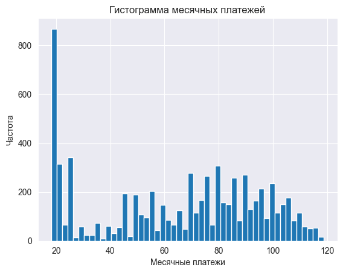

```python
df_contract['MonthlyCharges'].hist(bins=50)
plt.title('Гистограмма месячных платежей')
plt.xlabel('Месячные платежи')
plt.ylabel('Частота')
plt.show()
```

На графике видно, что большое количество пользователей платят мало за услуги компании (скорее всего они пользуются только базовыми услугами), а значит, что они могут легче расстаться с оператором и рассторгнуть договор.

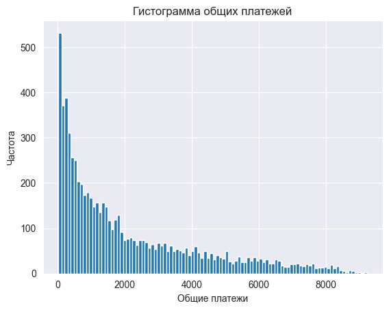

```python
df_contract['TotalCharges'].hist(bins=100)
plt.title('Гистограмма общих платежей')
plt.xlabel('Общие платежи')
plt.ylabel('Частота')
plt.show()
```

Распределение похоже на распределение Парето. Это может означать, что какая-то часть клиентов просто недавно пользуется нашими услугами, либо быстро расторгала договор, из-за чего их суммарные траты не оказались такими высокими.

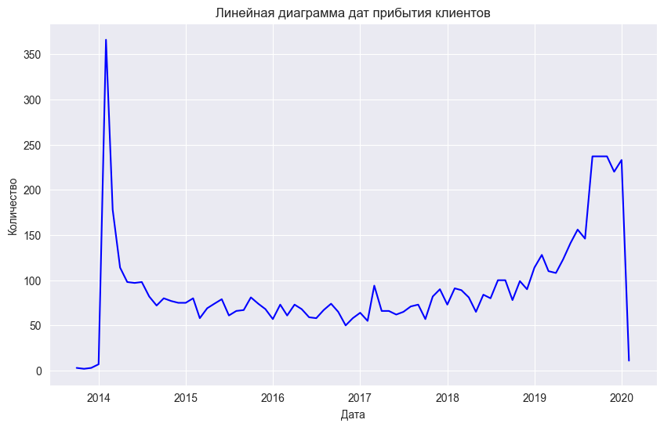

```python
daily_counts = df_contract.groupby(df_contract['BeginDate'].dt.date).size()

fig, ax = plt.subplots(figsize=(10, 6))
ax.plot(daily_counts.index, daily_counts.values, color='blue')

ax.set_xlabel('Дата')
ax.set_ylabel('Количество')
ax.set_title('Линейная диаграмма дат прибытия клиентов')

plt.show()
```

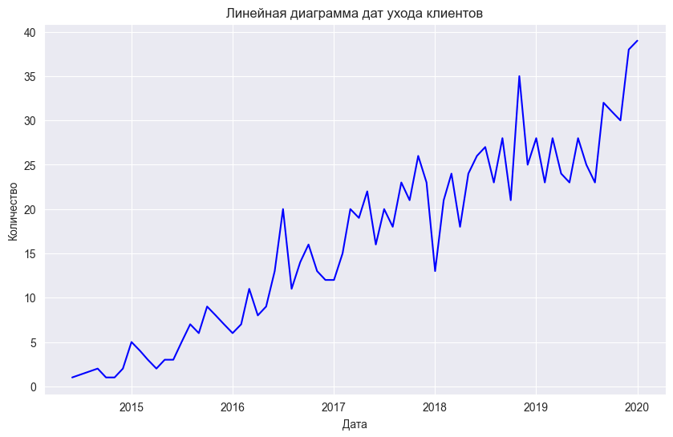

```python
daily_counts = df_contract.groupby(df_contract['EndDate'].dt.date).size()

fig, ax = plt.subplots(figsize=(10, 6))
ax.plot(daily_counts.index, daily_counts.values, color='blue')

ax.set_xlabel('Дата')
ax.set_ylabel('Количество')
ax.set_title('Линейная диаграмма дат ухода клиентов')

plt.show()
```

Линейные диаграммы дат прибытия и ухода клиентов это подтверждают.  
Действительно, за последние 2 года прирост количества клиентов заметно увеличился.  
И в это же время увеличился отток клиентов.

### Датасет "Интернет"

#### Предобработка данных

```python
df_internet.head()
```

|  | customerID | InternetService | OnlineSecurity | OnlineBackup | DeviceProtection | TechSupport | StreamingTV | StreamingMovies |
| --- | --- | --- | --- | --- | --- | --- | --- | --- |
| 0 | 7590-VHVEG | DSL | No | Yes | No | No | No | No |
| 1 | 5575-GNVDE | DSL | Yes | No | Yes | No | No | No |
| 2 | 3668-QPYBK | DSL | Yes | Yes | No | No | No | No |
| 3 | 7795-CFOCW | DSL | Yes | No | Yes | Yes | No | No |
| 4 | 9237-HQITU | Fiber optic | No | No | No | No | No | No |

```python
df_internet.info()
```

```
<class 'pandas.core.frame.DataFrame'>
RangeIndex: 5517 entries, 0 to 5516
Data columns (total 8 columns):
 #   Column            Non-Null Count  Dtype
---  ------            --------------  -----
 0   customerID        5517 non-null   object
 1   InternetService   5517 non-null   object
 2   OnlineSecurity    5517 non-null   object
 3   OnlineBackup      5517 non-null   object
 4   DeviceProtection  5517 non-null   object
 5   TechSupport       5517 non-null   object
 6   StreamingTV       5517 non-null   object
 7   StreamingMovies   5517 non-null   object
dtypes: object(8)
memory usage: 344.9+ KB
```

Типы данных соответствуют верным. Проверим ID клиентов на наличие дупликатов.

```python
df_internet['customerID'].duplicated().sum()
```

```
0
```

Дупликатов нет. Теперь проверим данные на опечатки.

```python
for col in df_internet.drop(['customerID'], axis=1):
    print(f'Уникальные значения в {col}: {df_internet[col].unique()}')
```

```
Уникальные значения в InternetService: ['DSL' 'Fiber optic']
Уникальные значения в OnlineSecurity: ['No' 'Yes']
Уникальные значения в OnlineBackup: ['Yes' 'No']
Уникальные значения в DeviceProtection: ['No' 'Yes']
Уникальные значения в TechSupport: ['No' 'Yes']
Уникальные значения в StreamingTV: ['No' 'Yes']
Уникальные значения в StreamingMovies: ['No' 'Yes']
```

Всё в порядке.

#### Визуализация данных

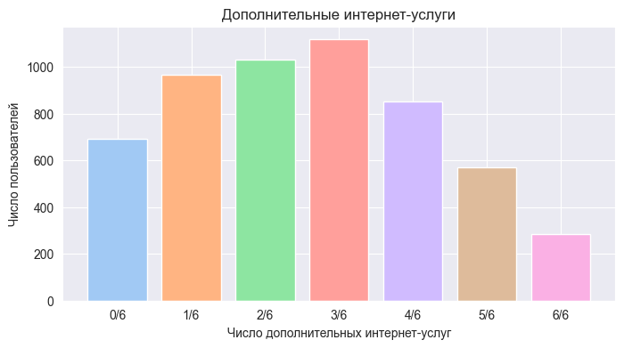

```python
df_internet['num_services'] = (df_internet == 'Yes').sum(axis=1)

counts = df_internet['num_services'].value_counts().sort_index()

colors = sns.color_palette('pastel', len(counts))

fig, ax = plt.subplots(figsize=(8, 4))
ax.bar([f'{i}/6' for i in counts.index], counts, color=colors)
ax.set_xlabel('Число дополнительных интернет-услуг')
ax.set_ylabel('Число пользователей')
ax.set_title('Дополнительные интернет-услуги')

plt.show()
df_internet.drop('num_services', axis=1, inplace=True)
```

На графике заметно, что существует большое количество клиентов, пользующихся базовой линейкой услуг. Но также можно увидеть, что количество людей, оформивших половину и более доп. услуг, достаточно много, что можно считать успехом для оператора. Скорее всего именно такие пользователи будут оставаться лояльными, так как зависимы сразу от нескольких услуг.

### Датасет "Персональные данные"

#### Предобработка данных

```python
df_personal.head()
```

|  | customerID | gender | SeniorCitizen | Partner | Dependents |
| --- | --- | --- | --- | --- | --- |
| 0 | 7590-VHVEG | Female | 0 | Yes | No |
| 1 | 5575-GNVDE | Male | 0 | No | No |
| 2 | 3668-QPYBK | Male | 0 | No | No |
| 3 | 7795-CFOCW | Male | 0 | No | No |
| 4 | 9237-HQITU | Female | 0 | No | No |

```python
df_personal.info()
```

```
<class 'pandas.core.frame.DataFrame'>
RangeIndex: 7043 entries, 0 to 7042
Data columns (total 5 columns):
 #   Column         Non-Null Count  Dtype
---  ------         --------------  -----
 0   customerID     7043 non-null   object
 1   gender         7043 non-null   object
 2   SeniorCitizen  7043 non-null   int64
 3   Partner        7043 non-null   object
 4   Dependents     7043 non-null   object
dtypes: int64(1), object(4)
memory usage: 275.2+ KB
```

Типы данных соответствуют верным. Проверим ID клиентов на наличие дупликатов.

```python
df_personal['customerID'].duplicated().sum()
```

```
0
```

Дупликатов нет. Теперь проверим данные на опечатки.

```python
for col in df_personal.drop(['customerID'], axis=1):
    print(f'Уникальные значения в {col}: {df_personal[col].unique()}')
```

```
Уникальные значения в gender: ['Female' 'Male']
Уникальные значения в SeniorCitizen: [0 1]
Уникальные значения в Partner: ['Yes' 'No']
Уникальные значения в Dependents: ['No' 'Yes']
```

Всё в порядке.

#### Визуализация данных

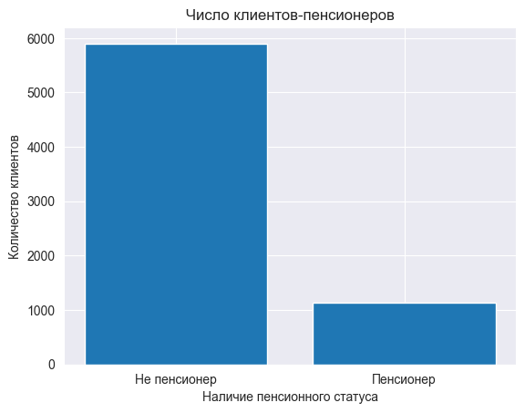

```python
df_personal['SeniorCitizenLabel'] = df_personal['SeniorCitizen'].map({0: 'Не пенсионер', 1: 'Пенсионер'})

counts = df_personal['SeniorCitizenLabel'].value_counts()

fig, ax = plt.subplots()
ax.bar(counts.index, counts.values)

ax.set_xlabel('Наличие пенсионного статуса')
ax.set_ylabel('Количество клиентов')
ax.set_title('Число клиентов-пенсионеров')

plt.show()
df_personal.drop('SeniorCitizenLabel', axis=1, inplace=True)
```

### Датасет "Телефония"

#### Предобработка данных

```python
df_phone.head()
```

|  | customerID | MultipleLines |
| --- | --- | --- |
| 0 | 5575-GNVDE | No |
| 1 | 3668-QPYBK | No |
| 2 | 9237-HQITU | No |
| 3 | 9305-CDSKC | Yes |
| 4 | 1452-KIOVK | Yes |

```python
df_phone.info()
```

```
<class 'pandas.core.frame.DataFrame'>
RangeIndex: 6361 entries, 0 to 6360
Data columns (total 2 columns):
 #   Column         Non-Null Count  Dtype
---  ------         --------------  -----
 0   customerID     6361 non-null   object
 1   MultipleLines  6361 non-null   object
dtypes: object(2)
memory usage: 99.5+ KB
```

Типы данных соответствуют верным. Проверим ID клиентов на наличие дупликатов.

```python
df_phone['customerID'].duplicated().sum()
```

```
0
```

Дупликатов нет. Теперь проверим данные на опечатки.

```python
print(f"Уникальные значения в MultipleLines: {df_phone['MultipleLines'].unique()}")
```

```
Уникальные значения в MultipleLines: ['No' 'Yes']
```

Всё в порядке.

#### Визуализация данных

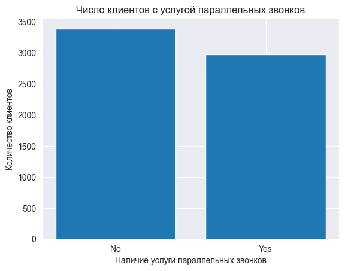

```python
counts = df_phone['MultipleLines'].value_counts()

fig, ax = plt.subplots()
ax.bar(counts.index, counts.values)

ax.set_xlabel('Наличие услуги параллельных звонков')
ax.set_ylabel('Количество клиентов')
ax.set_title('Число клиентов с услугой параллельных звонков')

plt.show()
```

Почти половина клиентов подключили услугу параллельных вызовов/удержания вызова. Это можно считать маленьким успехом компании.

Приступим к подготовке всех этих данных к обучению.

# План работы

1. Подготовка данных: После исследования датасетов стоит начать подготовку данных, которая будет заключаться в объеденении датасетов и заполнения появившихся пропусков. Этот шаг важен для обеспечения чистоты данных и их готовности к дальнейшему обучению.
2. Feature Engineering: Извлечение значимой информации из изначальных данных путем создания новых характеристик или преобразования существующих. Например, вы можем рассчитать как долго клиент пользуется услугами оператора.
3. Отбор признаков: Стоит изучить важность признаков. Проверить их на мультиколлинеарность и корреляцию с таргетом. После чего отобрать самые нужные на основе результатов обучения моделей.
4. Выбор и обучение модели: Мы выберем подходящие модели для бинарной классификации и обучим их на наборе данных. Попробуем различные модели, такие как логистическая регрессия, Random Forest или Gradient Boosting, и оценим их с помощью метрики AUC-ROC.
5. Настройка гиперпараметров: Настроим гиперпараметры модели, показавшей наилучшие результаты, чтобы улучшить ее производительность. Используем кросс-валидацию, чтобы избежать чрезмерной подгонки, и попробуем различные комбинации гиперпараметров.
6. Оценка модели: Наконец, оценим лучшую модель на тестовом наборе данных с помощью метрики AUC-ROC. Если пороговое значение на тестовой выборке будет меньше 0.85, отрегулируем его до достижения желаемого порога. Как только модель станет удовлетворительной, её можно будет развернуть для использования в производстве.

## Подготовка данных к обучению

```python
print(f"Размер датасета 'Контракты': {df_contract.shape}")
print(f"Размер датасета 'Интернет' {df_internet.shape}")
print(f"Размер датасета 'Персональные данные' {df_personal.shape}")
print(f"Размер датасета 'Телефония' {df_phone.shape}")
```

```
Размер датасета 'Контракты': (7043, 8)
Размер датасета 'Интернет' (5517, 8)
Размер датасета 'Персональные данные' (7043, 5)
Размер датасета 'Телефония' (6361, 2)
```

Объединим все датасеты по общему customerID. Мёрдж будет внешним, так мы сохраним те данные по ID, которые отсутствуют в некоторых столбцах.

```python
merged_df = pd.merge(df_contract, df_internet, on='customerID', how='outer')
merged_df = pd.merge(merged_df, df_personal, on='customerID', how='outer')
merged_df = pd.merge(merged_df, df_phone, on='customerID', how='outer')
```

```python
print(f"Размер общего датасета: {merged_df.shape}")
```

```
Размер общего датасета: (7043, 20)
```

Как видно из размеров, данные не были потеряны.

```python
merged_df.info()
```

```
<class 'pandas.core.frame.DataFrame'>
Int64Index: 7043 entries, 0 to 7042
Data columns (total 20 columns):
 #   Column            Non-Null Count  Dtype
---  ------            --------------  -----
 0   customerID        7043 non-null   object
 1   BeginDate         7043 non-null   datetime64[ns]
 2   EndDate           1101 non-null   datetime64[ns]
 3   Type              7043 non-null   object
 4   PaperlessBilling  7043 non-null   object
 5   PaymentMethod     7043 non-null   object
 6   MonthlyCharges    7043 non-null   float64
 7   TotalCharges      7043 non-null   float64
 8   InternetService   5517 non-null   object
 9   OnlineSecurity    5517 non-null   object
 10  OnlineBackup      5517 non-null   object
 11  DeviceProtection  5517 non-null   object
 12  TechSupport       5517 non-null   object
 13  StreamingTV       5517 non-null   object
 14  StreamingMovies   5517 non-null   object
 15  gender            7043 non-null   object
 16  SeniorCitizen     7043 non-null   int64
 17  Partner           7043 non-null   object
 18  Dependents        7043 non-null   object
 19  MultipleLines     6361 non-null   object
dtypes: datetime64[ns](2), float64(2), int64(1), object(15)
memory usage: 1.1+ MB
```

Изменим стиль названий столбцов с Camel на python.

```python
new_names = {}
for col in merged_df.columns:
    if col == 'StreamingTV':
        new_names[col] = 'streaming_tv'
    elif col == 'customerID':
        new_names[col] = 'customer_id'
    else:
        new_names[col] = col[0].lower() + ''.join(['_' + c.lower() if c.isupper() else c for c in col[1:]])

merged_df = merged_df.rename(columns=new_names)
```

```python
merged_df.head(5)
```

|  | customer_id | begin_date | end_date | type | paperless_billing | payment_method | monthly_charges | total_charges | internet_service | online_security | online_backup | device_protection | tech_support | streaming_tv | streaming_movies | gender | senior_citizen | partner | dependents | multiple_lines |
| --- | --- | --- | --- | --- | --- | --- | --- | --- | --- | --- | --- | --- | --- | --- | --- | --- | --- | --- | --- | --- |
| 0 | 7590-VHVEG | 2020-01-01 | NaT | Month-to-month | Yes | Electronic check | 29.85 | 31.04 | DSL | No | Yes | No | No | No | No | Female | 0 | Yes | No | NaN |
| 1 | 5575-GNVDE | 2017-04-01 | NaT | One year | No | Mailed check | 56.95 | 2071.84 | DSL | Yes | No | Yes | No | No | No | Male | 0 | No | No | No |
| 2 | 3668-QPYBK | 2019-10-01 | NaT | Month-to-month | Yes | Mailed check | 53.85 | 226.17 | DSL | Yes | Yes | No | No | No | No | Male | 0 | No | No | No |
| 3 | 7795-CFOCW | 2016-05-01 | NaT | One year | No | Bank transfer (automatic) | 42.30 | 1960.60 | DSL | Yes | No | Yes | Yes | No | No | Male | 0 | No | No | NaN |
| 4 | 9237-HQITU | 2019-09-01 | NaT | Month-to-month | Yes | Electronic check | 70.70 | 353.50 | Fiber optic | No | No | No | No | No | No | Female | 0 | No | No | No |

Перейдём к заполнению пропусков.  
Пропуски здесь имеются только из бывших таблиц "Интернет" и "Телефония".  
Пропуски возникают из-за того, что в этих таблицах отсутствует id клиента, что значит этой услугой он не пользуется.  
В столбцах из датасета "Интернет" заполним пропущенные значения словом "No".

```python
cols_fill_no = ['internet_service', 'online_security', 'online_backup', 'device_protection', 'tech_support',
                'streaming_tv', 'streaming_movies']
for col in cols_fill_no:
    merged_df[col] = merged_df[col].fillna('No')
```

В связи с характером столбца "multiple_lines" в наборе данных, где некоторые значения "No" фактически указывали бы на неиспользование услуг телефонии, мы решили заменить отсутствующие значения новой категорией "Not applicable" вместо "No". Это позволит провести различие между клиентами, которые вообще не пользуются услугами телефонии, и теми, кто пользуется ими, но не имеет нескольких линий.

```python
merged_df['multiple_lines'] = merged_df['multiple_lines'].fillna('Not applicable')
```

Пропуски успешно заполнены.

Мы завершили предобработку данных.  
Слили таблицы воедино и заполнили появивишиеся пропуски.  
Теперь можно приступить к анализу данных и обучению модели.

## Feature Engineering

```python
merged_df['days_of_using'] = (
        merged_df['end_date'].fillna(pd.to_datetime('2020-02-01')) - merged_df['begin_date']).dt.days
```

Получили количество дней, которое описывает как долго клиент пользуется нашим сервисом. Так как база данных актуальна на 01 февраля 2020 года, за "сегодняший день" была взята именно эта дата.

```python
def determine_left(row):
    if pd.isna(row['end_date']):
        return 0
    else:
        return 1
```

```python
merged_df['client_left'] = merged_df.apply(determine_left, axis=1)
```

Создали таргет, показывающий ушёл ли клиент:  
`1`- клиент ушёл,  
`0`- клиент остался.

```python
merged_df.head()
```

|  | customer_id | begin_date | end_date | type | paperless_billing | payment_method | monthly_charges | total_charges | internet_service | online_security | ... | tech_support | streaming_tv | streaming_movies | gender | senior_citizen | partner | dependents | multiple_lines | days_of_using | client_left |
| --- | --- | --- | --- | --- | --- | --- | --- | --- | --- | --- | --- | --- | --- | --- | --- | --- | --- | --- | --- | --- | --- |
| 0 | 7590-VHVEG | 2020-01-01 | NaT | Month-to-month | Yes | Electronic check | 29.85 | 31.04 | DSL | No | ... | No | No | No | Female | 0 | Yes | No | Not applicable | 31 | 0 |
| 1 | 5575-GNVDE | 2017-04-01 | NaT | One year | No | Mailed check | 56.95 | 2071.84 | DSL | Yes | ... | No | No | No | Male | 0 | No | No | No | 1036 | 0 |
| 2 | 3668-QPYBK | 2019-10-01 | NaT | Month-to-month | Yes | Mailed check | 53.85 | 226.17 | DSL | Yes | ... | No | No | No | Male | 0 | No | No | No | 123 | 0 |
| 3 | 7795-CFOCW | 2016-05-01 | NaT | One year | No | Bank transfer (automatic) | 42.30 | 1960.60 | DSL | Yes | ... | Yes | No | No | Male | 0 | No | No | Not applicable | 1371 | 0 |
| 4 | 9237-HQITU | 2019-09-01 | NaT | Month-to-month | Yes | Electronic check | 70.70 | 353.50 | Fiber optic | No | ... | No | No | No | Female | 0 | No | No | No | 153 | 0 |

5 rows × 22 columns

```python
merged_df = merged_df.drop(['customer_id', 'begin_date', 'end_date'], axis=1)
```

Эти признаки для обучения нам больше не нужны.

```python
phik_matrix = merged_df.phik_matrix()
phik_matrix
```

```
interval columns not set, guessing: ['monthly_charges', 'total_charges', 'senior_citizen', 'days_of_using', 'client_left']
```

|  | type | paperless_billing | payment_method | monthly_charges | total_charges | internet_service | online_security | online_backup | device_protection | tech_support | streaming_tv | streaming_movies | gender | senior_citizen | partner | dependents | multiple_lines | days_of_using | client_left |
| --- | --- | --- | --- | --- | --- | --- | --- | --- | --- | --- | --- | --- | --- | --- | --- | --- | --- | --- | --- |
| type | 1.000000 | 0.106860 | 0.277462 | 0.388444 | 0.468471 | 0.505187 | 0.152145 | 0.098884 | 0.137610 | 0.179999 | 0.066961 | 0.069608 | 0.000000 | 0.086231 | 0.179736 | 0.147680 | 0.244410 | 0.634155 | 0.094015 |
| paperless_billing | 0.106860 | 1.000000 | 0.370495 | 0.467812 | 0.203144 | 0.231438 | 0.000000 | 0.196443 | 0.160796 | 0.055929 | 0.343524 | 0.325551 | 0.000000 | 0.242133 | 0.013218 | 0.172593 | 0.099953 | 0.026799 | 0.083398 |
| payment_method | 0.277462 | 0.370495 | 1.000000 | 0.399526 | 0.335175 | 0.323886 | 0.262911 | 0.282475 | 0.306866 | 0.272101 | 0.377209 | 0.378907 | 0.000000 | 0.292725 | 0.243008 | 0.224903 | 0.174849 | 0.350964 | 0.214832 |
| monthly_charges | 0.388444 | 0.467812 | 0.399526 | 1.000000 | 0.711029 | 0.919002 | 0.551621 | 0.629541 | 0.667481 | 0.576525 | 0.835340 | 0.833307 | 0.008175 | 0.304985 | 0.203545 | 0.184366 | 0.709983 | 0.387727 | 0.226280 |
| total_charges | 0.468471 | 0.203144 | 0.335175 | 0.711029 | 1.000000 | 0.489674 | 0.521522 | 0.622643 | 0.641455 | 0.549866 | 0.642144 | 0.644671 | 0.000000 | 0.137707 | 0.381042 | 0.082134 | 0.467339 | 0.847414 | 0.304287 |
| internet_service | 0.505187 | 0.231438 | 0.323886 | 0.919002 | 0.489674 | 1.000000 | 0.241421 | 0.233602 | 0.232916 | 0.239663 | 0.272818 | 0.272782 | 0.000000 | 0.160702 | 0.000000 | 0.108463 | 0.739808 | 0.060845 | 0.056621 |
| online_security | 0.152145 | 0.000000 | 0.262911 | 0.551621 | 0.521522 | 0.241421 | 1.000000 | 0.430425 | 0.418474 | 0.528391 | 0.272186 | 0.289097 | 0.018397 | 0.057028 | 0.221673 | 0.124945 | 0.095572 | 0.395693 | 0.132594 |
| online_backup | 0.098884 | 0.196443 | 0.282475 | 0.629541 | 0.622643 | 0.233602 | 0.430425 | 1.000000 | 0.458211 | 0.445130 | 0.428007 | 0.417170 | 0.009882 | 0.102065 | 0.219223 | 0.031533 | 0.140081 | 0.414982 | 0.229482 |
| device_protection | 0.137610 | 0.160796 | 0.306866 | 0.667481 | 0.641455 | 0.232916 | 0.418474 | 0.458211 | 1.000000 | 0.499267 | 0.575536 | 0.589888 | 0.000000 | 0.090686 | 0.238079 | 0.010416 | 0.145710 | 0.426931 | 0.218380 |
| tech_support | 0.179999 | 0.055929 | 0.272101 | 0.576525 | 0.549866 | 0.239663 | 0.528391 | 0.445130 | 0.499267 | 1.000000 | 0.422242 | 0.424078 | 0.000000 | 0.092565 | 0.185993 | 0.096912 | 0.098571 | 0.404795 | 0.103652 |
| streaming_tv | 0.066961 | 0.343524 | 0.377209 | 0.835340 | 0.642144 | 0.272818 | 0.272186 | 0.428007 | 0.575536 | 0.422242 | 1.000000 | 0.742479 | 0.000000 | 0.163120 | 0.193258 | 0.017331 | 0.166899 | 0.339313 | 0.200198 |
| streaming_movies | 0.069608 | 0.325551 | 0.378907 | 0.833307 | 0.644671 | 0.272782 | 0.289097 | 0.417170 | 0.589888 | 0.424078 | 0.742479 | 1.000000 | 0.000000 | 0.186141 | 0.182011 | 0.058999 | 0.170432 | 0.339313 | 0.222232 |
| gender | 0.000000 | 0.000000 | 0.000000 | 0.008175 | 0.000000 | 0.000000 | 0.018397 | 0.009882 | 0.000000 | 0.000000 | 0.000000 | 0.000000 | 1.000000 | 0.000000 | 0.000000 | 0.000000 | 0.000000 | 0.000000 | 0.008581 |
| senior_citizen | 0.086231 | 0.242133 | 0.292725 | 0.304985 | 0.137707 | 0.160702 | 0.057028 | 0.102065 | 0.090686 | 0.092565 | 0.163120 | 0.186141 | 0.000000 | 1.000000 | 0.016992 | 0.324576 | 0.087925 | 0.063315 | 0.086159 |
| partner | 0.179736 | 0.013218 | 0.243008 | 0.203545 | 0.381042 | 0.000000 | 0.221673 | 0.219223 | 0.238079 | 0.185993 | 0.193258 | 0.182011 | 0.000000 | 0.016992 | 1.000000 | 0.652122 | 0.086249 | 0.453688 | 0.226688 |
| dependents | 0.147680 | 0.172593 | 0.224903 | 0.184366 | 0.082134 | 0.108463 | 0.124945 | 0.031533 | 0.010416 | 0.096912 | 0.017331 | 0.058999 | 0.000000 | 0.324576 | 0.652122 | 1.000000 | 0.011198 | 0.198729 | 0.046871 |
| multiple_lines | 0.244410 | 0.099953 | 0.174849 | 0.709983 | 0.467339 | 0.739808 | 0.095572 | 0.140081 | 0.145710 | 0.098571 | 0.166899 | 0.170432 | 0.000000 | 0.087925 | 0.086249 | 0.011198 | 1.000000 | 0.347289 | 0.105101 |
| days_of_using | 0.634155 | 0.026799 | 0.350964 | 0.387727 | 0.847414 | 0.060845 | 0.395693 | 0.414982 | 0.426931 | 0.404795 | 0.339313 | 0.339313 | 0.000000 | 0.063315 | 0.453688 | 0.198729 | 0.347289 | 1.000000 | 0.374569 |
| client_left | 0.094015 | 0.083398 | 0.214832 | 0.226280 | 0.304287 | 0.056621 | 0.132594 | 0.229482 | 0.218380 | 0.103652 | 0.200198 | 0.222232 | 0.008581 | 0.086159 | 0.226688 | 0.046871 | 0.105101 | 0.374569 | 1.000000 |

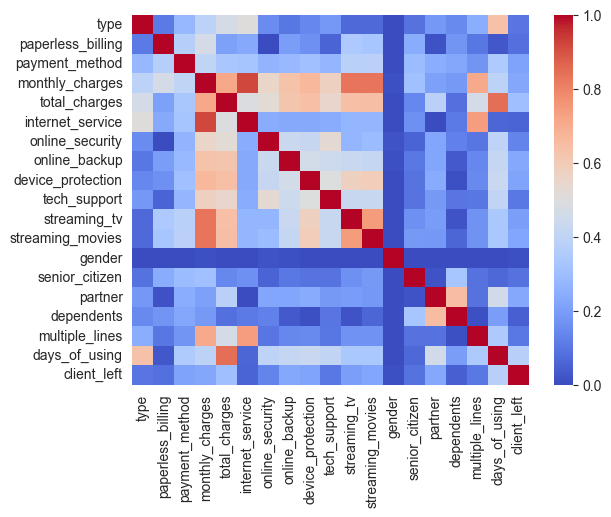

```python
sns.heatmap(phik_matrix, cmap='coolwarm')
plt.show()
```

Виднеется значительная корреляция между `total_charges` и `monthly_charges`. Это имеет смысл, так как общие затраты строятся на месячных. Тем более мы имеем количество дней, в течение которых клиент оплачивал услуги. `monthly_charges` возможно будет дропнут в дальнейшем.

Мы наблюдаем, что почти у каждого признака низкая корреляция с таргетом. Во время обучения моделей будем убирать признаки с наименьшей корреляцией и сравнивать результаты.

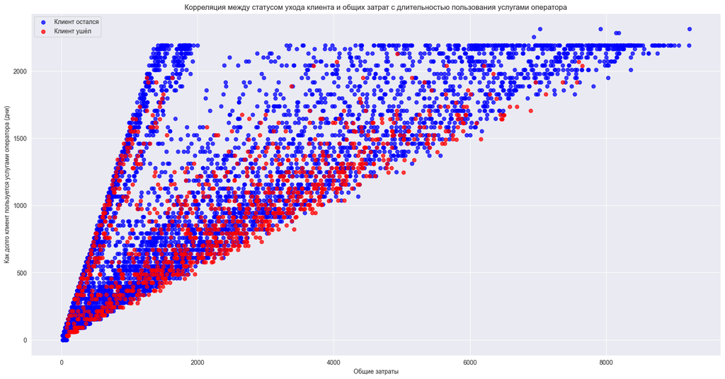

```python
x = merged_df['total_charges']
y = merged_df['days_of_using']
colors = merged_df['client_left']

plt.figure(figsize=(20, 10))
plt.scatter(x[colors == 0], y[colors == 0], c='blue', label='Клиент остался', alpha=0.75)
plt.scatter(x[colors == 1], y[colors == 1], c='red', label='Клиент ушёл', alpha=0.75)
plt.xlabel('Общие затраты')
plt.ylabel('Как долго клиент пользуется услугами оператора (дни)')
plt.title('Корреляция между статусом ухода клиента и общих затрат с длительностью пользования услугами оператора')
plt.legend()
plt.show()
```

Мы построили график корреляции между статусом ухода клиента и общих затрат с длительностью пользования услугами оператора.  
Эти признаки были взяты по причине самой высокой корреляции (среди всех остальных фичей) с таргетом, а также высокой корреляции друг с другом.  
Этот график подтвержает наши предыдущие предположения о том, что чаще всего именно люди с маленькими общими затратами и недолгим пользованием услугами покидают оператора.

## Обучение моделей

### Подготовка выборок

```python
merged_df['senior_citizen'] = merged_df['senior_citizen'].astype('object')
```

```python
X_train, X_test, y_train, y_test = train_test_split(
    merged_df.drop('client_left', axis=1),
    merged_df['client_left'],
    test_size=0.25,
    random_state=240423)
```

Разбили данные на выборки, а также на фичи и таргеты.

### Универсальная модель

```python
def train_model(X_train, y_train, pipeline, params):
    start_time = time.time()

    search = GridSearchCV(
        pipeline,
        param_grid=params,
        scoring='roc_auc',
        cv=StratifiedKFold(n_splits=5, shuffle=True, random_state=240423),
        n_jobs=-1
    )

    search.fit(X_train, y_train)

    end_time = time.time()
    duration = end_time - start_time

    return search.best_estimator_, search.best_score_, duration
```

Создали универсальную модель, в которую уже можем загружать нужные пайплайны и сетку параметров.  
На выходе мы будем получать лучшую модель, её оценку и длительность обучения.

### Дамми-модель

Кодировщик, основанный на OneHotEncoder, уместим внутрь пайплайнов, чтобы избежать утечки данных.

```python
best_dummy, AUC_dummy, time_dummy = train_model(
    X_train,
    y_train,
    Pipeline(
        [
            ('encoder', ColumnTransformer([('encoder', OneHotEncoder(drop='first', handle_unknown='ignore'),
                                            X_train.select_dtypes(include=['object']).columns.tolist())],
                                          remainder='passthrough')),
            ("scaler", StandardScaler()),
            ("oversampler", RandomOverSampler(random_state=240423)),
            ("dumm", DummyClassifier(random_state=240423)),
        ]
    ),
    params={
        "dumm__strategy": ["most_frequent"],
    },
)

print(f"Лучшая модель для дамми-модели: {best_dummy}")
print(f"Лучший AUC-ROC для дамми-модели: {AUC_dummy}")
print(f"Время полного обучения дамми-модели: {time_dummy} сек.")
```

```
Лучшая модель для дамми-модели: Pipeline(steps=[('encoder',
                 ColumnTransformer(remainder='passthrough',
                                   transformers=[('encoder',
                                                  OneHotEncoder(drop='first',
                                                                handle_unknown='ignore'),
                                                  ['type', 'paperless_billing',
                                                   'payment_method',
                                                   'internet_service',
                                                   'online_security',
                                                   'online_backup',
                                                   'device_protection',
                                                   'tech_support',
                                                   'streaming_tv',
                                                   'streaming_movies', 'gender',
                                                   'senior_citizen', 'partner',
                                                   'dependents',
                                                   'multiple_lines'])])),
                ('scaler', StandardScaler()),
                ('oversampler', RandomOverSampler(random_state=240423)),
                ('dumm',
                 DummyClassifier(random_state=240423,
                                 strategy='most_frequent'))])
Лучший AUC-ROC для дамми-модели: 0.5
Время полного обучения дамми-модели: 0.2722475528717041 сек.
```

Дамми-модель ожидаемо показала AUC-ROC, равный 0.5, всё-таки мы решаем задачу бинарной классификации.

Дабы избавиться от дисбаланса в данных (уходящих клиентов намного меньше оставшихся), мы воспользовались `RandomOverSampler` во всех моделях.

### Логистическая регрессия

```python
best_log, AUC_log, time_log = train_model(
    X_train,
    y_train,
    Pipeline(
        [
            ('encoder', ColumnTransformer([('encoder', OneHotEncoder(drop='first', handle_unknown='ignore'),
                                            X_train.select_dtypes(include=['object']).columns.tolist())],
                                          remainder='passthrough')),
            ("scaler", StandardScaler()),
            ("oversampler", RandomOverSampler(random_state=240423)),
            ("log", LogisticRegression(random_state=240423)),
        ]
    ),
    params={
        "log__C": np.arange(0.1, 10.1, 0.1),
        "log__max_iter": np.arange(100, 1000, 50),
        "log__solver": ["lbfgs", "saga"],
    },
)

print(f"Лучшая модель для логистической регрессии: {best_log}")
print(f"Лучший AUC-ROC для логистической регрессии: {AUC_log}")
print(f"Время полного обучения логистической регрессии: {time_log} сек.")
```

```
Лучшая модель для логистической регрессии: Pipeline(steps=[('encoder',
                 ColumnTransformer(remainder='passthrough',
                                   transformers=[('encoder',
                                                  OneHotEncoder(drop='first',
                                                                handle_unknown='ignore'),
                                                  ['type', 'paperless_billing',
                                                   'payment_method',
                                                   'internet_service',
                                                   'online_security',
                                                   'online_backup',
                                                   'device_protection',
                                                   'tech_support',
                                                   'streaming_tv',
                                                   'streaming_movies', 'gender',
                                                   'senior_citizen', 'partner',
                                                   'dependents',
                                                   'multiple_lines'])])),
                ('scaler', StandardScaler()),
                ('oversampler', RandomOverSampler(random_state=240423)),
                ('log',
                 LogisticRegression(C=0.1, random_state=240423,
                                    solver='saga'))])
Лучший AUC-ROC для логистической регрессии: 0.7665227177238277
Время полного обучения логистической регрессии: 110.74434852600098 сек.
```

Логистическая регрессия не достигла порога успеха.

Так как логистическая регрессия чувствительна к мультиколлинеарности, уберем признаки с высокими показателями мультиколлинеарности, которые мы выявили при помощи матрицы phik ранее, и посмотрим какое будет у модели качество.

```python
best_log_nm, AUC_log_nm, time_log_nm = train_model(
    X_train.drop(['internet_service',
                  'streaming_tv',
                  'streaming_tv',
                  'device_protection',
                  'online_backup',
                  'device_protection',
                  'online_security',
                  'tech_support',
                  'multiple_lines'], axis=1),
    y_train,
    Pipeline(
        [
            ('encoder', ColumnTransformer([('encoder', OneHotEncoder(drop='first', handle_unknown='ignore'),
                                            X_train.drop(['internet_service',
                                                          'streaming_tv',
                                                          'streaming_tv',
                                                          'device_protection',
                                                          'online_backup',
                                                          'device_protection',
                                                          'online_security',
                                                          'tech_support',
                                                          'multiple_lines'],
                                                         axis=1).select_dtypes(include=['object']).columns.tolist())],
                                          remainder='passthrough')),
            ("scaler", StandardScaler()),
            ("oversampler", RandomOverSampler(random_state=240423)),
            ("log", LogisticRegression(random_state=240423)),
        ]
    ),
    params={
        "log__C": np.arange(0.1, 10.1, 0.1),
        "log__max_iter": np.arange(100, 1000, 50),
        "log__solver": ["lbfgs", "saga"],
    },
)

print(f"Лучшая модель для логистической регрессии (без мультиколлинеарности): {best_log_nm}")
print(f"Лучший AUC-ROC для логистической регрессии (без мультиколлинеарности): {AUC_log_nm}")
print(f"Время полного обучения логистической регрессии (без мультиколлинеарности): {time_log_nm} сек.")
```

```
Лучшая модель для логистической регрессии (без мультиколлинеарности): Pipeline(steps=[('encoder',
                 ColumnTransformer(remainder='passthrough',
                                   transformers=[('encoder',
                                                  OneHotEncoder(drop='first',
                                                                handle_unknown='ignore'),
                                                  ['type', 'paperless_billing',
                                                   'payment_method',
                                                   'streaming_movies', 'gender',
                                                   'senior_citizen', 'partner',
                                                   'dependents'])])),
                ('scaler', StandardScaler()),
                ('oversampler', RandomOverSampler(random_state=240423)),
                ('log',
                 LogisticRegression(C=0.1, random_state=240423,
                                    solver='saga'))])
Лучший AUC-ROC для логистической регрессии (без мультиколлинеарности): 0.7434441944146761
Время полного обучения логистической регрессии (без мультиколлинеарности): 32.85375905036926 сек.
```

Даже после дропа фичей логистическая регрессия не смогла достигнуть нужного результата.

### Случайный лес

```python
best_rf, AUC_rf, time_rf = train_model(
    X_train,
    y_train,
    Pipeline(
        [
            ('encoder', ColumnTransformer([('encoder', OneHotEncoder(drop='first', handle_unknown='ignore'),
                                            X_train.select_dtypes(include=['object']).columns.tolist())],
                                          remainder='passthrough')),
            ("scaler", StandardScaler()),
            ("oversampler", RandomOverSampler(random_state=240423)),
            ("rf", RandomForestClassifier(random_state=240423)),
        ]
    ),
    params={
        'rf__n_estimators': np.arange(1, 201, 20),
        'rf__max_depth': np.arange(1, 21),
        'rf__min_samples_leaf': np.arange(1, 5)
    },
)

print(f"Лучшая модель для случайного леса: {best_rf}")
print(f"Лучший AUC-ROC для случайного леса: {AUC_rf}")
print(f"Время полного обучения случайного леса: {time_rf} сек.")
```

```
Лучшая модель для случайного леса: Pipeline(steps=[('encoder',
                 ColumnTransformer(remainder='passthrough',
                                   transformers=[('encoder',
                                                  OneHotEncoder(drop='first',
                                                                handle_unknown='ignore'),
                                                  ['type', 'paperless_billing',
                                                   'payment_method',
                                                   'internet_service',
                                                   'online_security',
                                                   'online_backup',
                                                   'device_protection',
                                                   'tech_support',
                                                   'streaming_tv',
                                                   'streaming_movies', 'gender',
                                                   'senior_citizen', 'partner',
                                                   'dependents',
                                                   'multiple_lines'])])),
                ('scaler', StandardScaler()),
                ('oversampler', RandomOverSampler(random_state=240423)),
                ('rf',
                 RandomForestClassifier(max_depth=8, min_samples_leaf=4,
                                        n_estimators=141,
                                        random_state=240423))])
Лучший AUC-ROC для случайного леса: 0.8174006855818388
Время полного обучения случайного леса: 80.04682636260986 сек.
```

Лес уже точнее предсказывает таргет, чем логистическая регрессия, но точности всё ещё не хватает.

### LightGBM

```python
best_lgbm, AUC_lgbm, time_lgbm = train_model(
    X_train,
    y_train,
    Pipeline(
        [
            ('encoder', ColumnTransformer([('encoder', OneHotEncoder(drop='first', handle_unknown='ignore'),
                                            X_train.select_dtypes(include=['object']).columns.tolist())],
                                          remainder='passthrough')),
            ("scaler", StandardScaler()),
            ("oversampler", RandomOverSampler(random_state=240423)),
            ("lgbm", lgb.LGBMClassifier(random_state=240423)),
        ]
    ),
    params={
        'lgbm__objective': ['binary'],
        'lgbm__metric': ['auc'],
        'lgbm__num_leaves': np.arange(2, 50, 1),
        'lgbm__n_estimators': np.arange(1, 201, 10),
        'lgbm__learning_rate': np.arange(0.1, 1.1, 0.1)
    },
)

print(f"Лучшая модель для LightGBM: {best_lgbm}")
print(f"Лучший AUC-ROC для LightGBM: {AUC_lgbm}")
print(f"Время полного обучения LightGBM: {time_lgbm} сек.")
```

```
Лучшая модель для LightGBM: Pipeline(steps=[('encoder',
                 ColumnTransformer(remainder='passthrough',
                                   transformers=[('encoder',
                                                  OneHotEncoder(drop='first',
                                                                handle_unknown='ignore'),
                                                  ['type', 'paperless_billing',
                                                   'payment_method',
                                                   'internet_service',
                                                   'online_security',
                                                   'online_backup',
                                                   'device_protection',
                                                   'tech_support',
                                                   'streaming_tv',
                                                   'streaming_movies', 'gender',
                                                   'senior_citizen', 'partner',
                                                   'dependents',
                                                   'multiple_lines'])])),
                ('scaler', StandardScaler()),
                ('oversampler', RandomOverSampler(random_state=240423)),
                ('lgbm',
                 LGBMClassifier(learning_rate=0.5, metric='auc',
                                n_estimators=191, num_leaves=6,
                                objective='binary', random_state=240423))])
Лучший AUC-ROC для LightGBM: 0.9018250565706879
Время полного обучения LightGBM: 323.96237659454346 сек.
```

```python
feature_transformer = best_lgbm.named_steps["encoder"].get_feature_names_out()
```

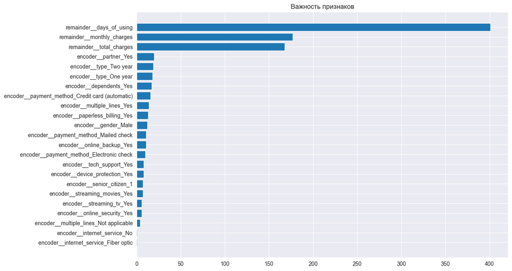

```python
feature_importance = best_lgbm._final_estimator.feature_importances_
sorted_idx = np.argsort(feature_importance)
fig = plt.figure(figsize=(12, 8))
plt.barh(range(len(sorted_idx)), feature_importance[sorted_idx], align='center')
plt.yticks(range(len(sorted_idx)), np.array(feature_transformer)[sorted_idx])
plt.title('Важность признаков');
```

Самым важным признаком для предсказания ухода клиента оказалось количество дней, показывающее насколько долго клиент пользуется услугами оператора. Вот признаки, на которые следует обратить внимание:

- Как давно клиент пользуется услугами оператора;
- Размер ежемесячного платежа;
- Общая сумма платежей клиента;
- Наличие партнёра;
- Вид контракта;
- Наличие иждивенцев;
- Тип оплаты;
- Наличие услуги параллельных звонков.

Оставим только эти признаки и посмотрим, улучшится ли модель.

```python
best_lgbm_drop, AUC_lgbm_drop, time_lgbm_drop = train_model(
    X_train[['days_of_using',
             'total_charges',
             'monthly_charges',
             'partner',
             'payment_method',
             'type',
             'dependents',
             'multiple_lines']],
    y_train,
    Pipeline(
        [
            ('encoder', ColumnTransformer([('encoder', OneHotEncoder(drop='first', handle_unknown='ignore'),
                                            X_train[['days_of_using',
                                                     'total_charges',
                                                     'monthly_charges',
                                                     'partner',
                                                     'payment_method',
                                                     'type',
                                                     'dependents',
                                                     'multiple_lines']].select_dtypes(
                                                include=['object']).columns.tolist())],
                                          remainder='passthrough')),
            ("scaler", StandardScaler()),
            ("oversampler", RandomOverSampler(random_state=240423)),
            ("lgbm", lgb.LGBMClassifier(random_state=240423)),
        ]
    ),
    params={
        'lgbm__objective': ['binary'],
        'lgbm__metric': ['auc'],
        'lgbm__num_leaves': np.arange(2, 50, 1),
        'lgbm__n_estimators': np.arange(1, 201, 10),
        'lgbm__learning_rate': np.arange(0.1, 1.1, 0.1)
    },
)

print(f"Лучшая модель для LightGBM (только важные фичи): {best_lgbm_drop}")
print(f"Лучший AUC-ROC для LightGBM (только важные фичи): {AUC_lgbm_drop}")
print(f"Время полного обучения LightGBM (только важные фичи): {time_lgbm_drop} сек.")
```

```
Лучшая модель для LightGBM (только важные фичи): Pipeline(steps=[('encoder',
                 ColumnTransformer(remainder='passthrough',
                                   transformers=[('encoder',
                                                  OneHotEncoder(drop='first',
                                                                handle_unknown='ignore'),
                                                  ['partner', 'payment_method',
                                                   'type', 'dependents',
                                                   'multiple_lines'])])),
                ('scaler', StandardScaler()),
                ('oversampler', RandomOverSampler(random_state=240423)),
                ('lgbm',
                 LGBMClassifier(learning_rate=0.30000000000000004, metric='auc',
                                n_estimators=191, num_leaves=9,
                                objective='binary', random_state=240423))])
Лучший AUC-ROC для LightGBM (только важные фичи): 0.9089213727490438
Время полного обучения LightGBM (только важные фичи): 204.94702887535095 сек.
```

Действительно, модель показала оценку выше после того, как менее важные признаки были отброшены.

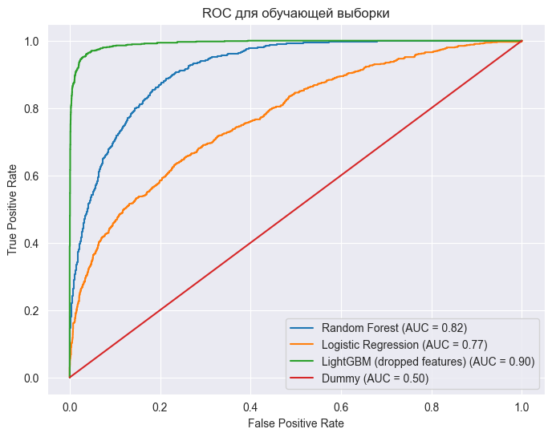

```python
fpr_rf_train, tpr_rf_train, _ = roc_curve(y_train, best_rf.predict_proba(X_train)[:, 1])
fpr_logreg_train, tpr_logreg_train, _ = roc_curve(y_train, best_log.predict_proba(X_train)[:, 1])
fpr_lgbm_train, tpr_lgbm_train, _ = roc_curve(y_train, best_lgbm_drop.predict_proba(X_train)[:, 1])
fpr_dummy_train, tpr_dummy_train, _ = roc_curve(y_train, best_dummy.predict_proba(X_train)[:, 1])

roc_curve_displays_train = [
    RocCurveDisplay(
        fpr=fpr_train, tpr=tpr_train, roc_auc=auc_train, estimator_name=name
    )
    for fpr_train, tpr_train, auc_train, name in [
        (fpr_rf_train, tpr_rf_train, AUC_rf, "Random Forest"),
        (fpr_logreg_train, tpr_logreg_train, AUC_log, "Logistic Regression"),
        (fpr_lgbm_train, tpr_lgbm_train, AUC_lgbm, "LightGBM (dropped features)"),
        (fpr_dummy_train, tpr_dummy_train, AUC_dummy, "Dummy")
    ]
]

fig, ax = plt.subplots(figsize=(8, 6))
for roc_curve_display_train in roc_curve_displays_train:
    roc_curve_display_train.plot(ax=ax)
plt.title('ROC для обучающей выборки')
plt.legend()
plt.show()
```

Каждая модель смогла выдать более точные предсказания, чем дамми-модель. Это уже микро-успех.

Можно заметить, что кривая LightGBM быстро растет, а затем медленно выравнивается, что указывает на то, что модель способна достичь высокого показателя истинных положительных результатов (TPR) при относительно небольшом увеличении показателя ложных положительных результатов (FPR). Это говорит о том, что модель способна хорошо разделять положительные и отрицательные классы и имеет хороший баланс между чувствительностью и полнотой.

С другой стороны, кривая логистической регрессии близка к диагональной, что говорит о том, что модель не способна достичь высокого TPR без высокого FPR. Это может указывать на то, что модель не способна разделять классы так же хорошо, как другие модели.

Наконец, кривая случайного леса находится где-то посередине. Она не такая крутая, как кривая LightGBM, но и не такая "диагональная", как кривая логистической регрессии. Это говорит о том, что модель способна достаточно хорошо разделять классы, но, возможно, не так эффективно, как модель LightGBM.

```python
model_names = ['Dummy', 'LogReg', 'LogReg (no multicorr)', 'RandomForest', 'LightGBM', 'LightGBM (dropped features)']
auc_roc_scores = [AUC_dummy, AUC_log, AUC_log_nm, AUC_rf, AUC_lgbm, AUC_lgbm_drop]
learning_times = [time_dummy, time_log, time_log_nm, time_rf, time_lgbm, time_lgbm_drop]


compare_table = pd.DataFrame({
    'Модель': model_names,
    'AUC-ROC точность': auc_roc_scores,
    'Время обучения (с)': learning_times
})

compare_table.set_index('Модель', inplace=True)

compare_table
```

| Модель | AUC-ROC точность | Время обучения (с) |
| --- | --- | --- |
| Dummy | 0.500000 | 0.272248 |
| LogReg | 0.766523 | 110.744349 |
| LogReg (no multicorr) | 0.743444 | 32.853759 |
| RandomForest | 0.817401 | 80.046826 |
| LightGBM | 0.901825 | 323.962377 |
| LightGBM (dropped features) | 0.908921 | 204.947029 |

LightGBM справилась со своей задачей. Она оказалась лучшей в плане точности, а также в свою очередь достигла порога для AUC_ROC (>= 0.85). Пора приступать к тестам. Посмотрим, как проявит себя бустинг там.

## Тестирование

```python
def test(pipe, X_test, y_test, threshold=0.5):
    predictions_prob = pipe.predict_proba(X_test)
    predictions = (predictions_prob[:, 1] >= threshold).astype(int)
    auc_roc_value = roc_auc_score(y_test, predictions_prob[:, 1])
    acc_roc_value = accuracy_score(y_test, predictions)

    return auc_roc_value, acc_roc_value, predictions
```

```python
auc_roc_test_lgbm_drop, acc_test_lgbm_drop, test_predictions_drop = test(best_lgbm_drop,
                                                                         X_test,
                                                                         y_test)
print(f"AUC_ROC для LightGBM только с важными фичами (тестовая выборка) равен: {auc_roc_test_lgbm_drop}")
print(f"Accuracy для LightGBM только с важными фичами (тестовая выборка) равен: {acc_test_lgbm_drop}")
```

```
AUC_ROC для LightGBM только с важными фичами (тестовая выборка) равен: 0.9200023725159501
Accuracy для LightGBM только с важными фичами (тестовая выборка) равен: 0.8779102782509938
```

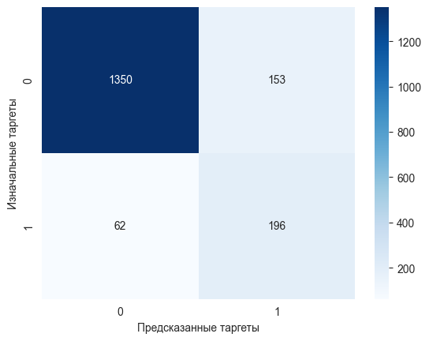

```python
cm = confusion_matrix(y_test, test_predictions_drop)

sns.heatmap(cm, annot=True, cmap='Blues', fmt='g')
plt.xlabel('Предсказанные таргеты')
plt.ylabel('Изначальные таргеты')
plt.show()
```

Порог в 0.85 AUC-ROC был достигнут. Модель показала оценку 0.92. Accuracy показала тоже высокий результат ~0.88.

## Отчёт

### Обзор проекта

Этот проект предполагал создание модели машинного обучения для прогнозирования оттока клиентов (а именно поиск клиентов, собирающихся уйти) оператора связи "Ниединогоразрыва.ком".

Так как мы решали задачу бинарной классификации, в которой наблюдался дисбаланс классов, мы воспользовались метрикой AUC-ROC для поиска лучшей модели (пороговое значение на тестовой выборке должно было быть не меньше 0.85).

Мы подошли к решению проблемы, сначала загрузив предоставленные данные, обработав их, а затем использовав для обучения нескольких моделей.  
После длительных экспериментов мы выбрали окончательную модель, которая дала наилучшие результаты, и оценили ее на тестовом наборе.

### Загрузка и предобработка данных

Мы получили данные от заказчика, которые включали 4 csv-файла:

- Информация о контрактах клиентов;
- Информация об интернет-услугах клиентов;
- Информация об услугах телефонии клиентов;
- Персональная информация клиентов.

Также для каждого датасета были построены графики благодаря которым можно проанализировать текущую ситуацию с клиентами.

После всего этого датасеты были слиты в одиный единый датасет для последующей обработки.

### Feature Enginering

При помощи информации о датах подписания и расторжения (либо же даты актуальности БД, если клиент не ушёл) контрактов мы смогли получить количество дней, показывающее как давно клиент пользуется услугами оператора.

После этого на основе столбца с датой окончания контракта мы вывели наш таргет, отвечающий за то, ушёл ли наш клиент (где 1 - ушёл, а 0 - не ушёл).

Мы убрали столбцы с датой, так как они больше не были нужна нам. После чего разделили весь датасет на обучающую и тестовую выборки (в соотношении 3:1), а также на признаки и таргет.

Категориальные признаки преобразовывались в численные при помощи OneHotEncoder'а внутри пайплайнов, а численные масштабировались при помощи StandartScaler'а также внутри пайплайнов.

`random_state` как здесь, так и во всех моделях и функциях был равен `240423`.

### Выбор модели

Мы экспериментировали с различными моделями машинного обучения, включая `LogisticRegression`, `RandomForestClassifier` и `LightGBM` и оценивали их производительность.

LightGBM показала лучший результат (AUC-ROC = 0.9), после чего на основе обучения этой модели был построен график важности признаков.

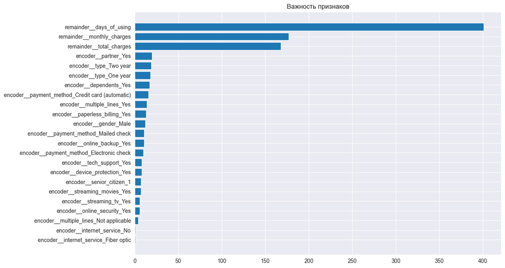

```python
fig = plt.figure(figsize=(12, 8))
plt.barh(range(len(sorted_idx)), feature_importance[sorted_idx], align='center')
plt.yticks(range(len(sorted_idx)), np.array(feature_transformer)[sorted_idx])
plt.title('Важность признаков');
```

Дабы улучшить модель мы оставили только важные признаки:

- Как давно клиент пользуется услугами оператора;
- Размер ежемесячного платежа;
- Общая сумма платежей клиента;
- Наличие партнёра;
- Вид контракта;
- Наличие иждивенцев;
- Тип оплаты;
- Наличие услуги параллельных звонков.

И уже после этого модель снова была обучена на том же словаре параметров. Точность увеличилась (с 0.901 до 0.908).

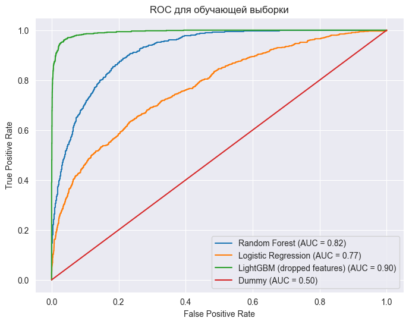

```python
fig, ax = plt.subplots(figsize=(8, 6))
for roc_curve_display_train in roc_curve_displays_train:
    roc_curve_display_train.plot(ax=ax)
plt.title('ROC для обучающей выборки')
plt.legend()
plt.show()
```

Можно заметить, что кривая LightGBM быстро растет, а затем медленно выравнивается, что указывает на то, что модель способна достичь высокого показателя истинных положительных результатов (TPR) при относительно небольшом увеличении показателя ложных положительных результатов (FPR). Это говорит о том, что модель способна хорошо разделять положительные и отрицательные классы и имеет хороший баланс между чувствительностью и полнотой.

С другой стороны, кривая логистической регрессии близка к диагональной, что говорит о том, что модель не способна достичь высокого TPR без высокого FPR. Это может указывать на то, что модель не способна разделять классы так же хорошо, как другие модели.

Наконец, кривая случайного леса находится где-то посередине. Она не такая крутая, как кривая LightGBM, но и не такая "диагональная", как кривая логистической регрессии. Это говорит о том, что модель способна достаточно хорошо разделять классы, но, возможно, не так эффективно, как модель LightGBM.

```python
compare_table
```

| Модель | AUC-ROC точность | Время обучения (с) |
| --- | --- | --- |
| Dummy | 0.500000 | 0.272248 |
| LogReg | 0.766523 | 110.744349 |
| LogReg (no multicorr) | 0.743444 | 32.853759 |
| RandomForest | 0.817401 | 80.046826 |
| LightGBM | 0.901825 | 323.962377 |
| LightGBM (dropped features) | 0.908921 | 204.947029 |

### Настройка гиперпараметров

У лучшей модели (LightGBM) гипермараметры подбирались при помощи `GridSearchCV`. Кросс-валидация внутри гридсёрча выполнялась при помощи `StratifiedKFold` (количество фолдов - 5). Словарь гиперпараметров выглядел так:

- ```
     'objective': ['binary'],
  ```

- ```
     'metric': ['auc'],
  ```

- ```
     'num_leaves': np.arange(2, 50, 1),
  ```

- ```
     'n_estimators': np.arange(1, 201, 10),
  ```

- ```
     'learning_rate': np.arange(0.1, 1.1, 0.1)
  ```

### Окончательная модель

В итоге мы получили такую модель:

```
pyhton
Pipeline(steps=[('encoder',
                 ColumnTransformer(remainder='passthrough',
                                   transformers=[('encoder',
                                                  OneHotEncoder(drop='first',
                                                                handle_unknown='ignore'),
                                                  ['partner', 'payment_method',
                                                   'type', 'dependents',
                                                   'multiple_lines'])])),
                ('scaler', StandardScaler()),
                ('oversampler', RandomOverSampler(random_state=240423)),
                ('lgbm',
                 LGBMClassifier(learning_rate=0.30000000000000004, metric='auc',
                                n_estimators=191, num_leaves=9,
                                objective='binary', random_state=240423))])
```

### Тестирование модели

После прогонки этой модели на тестовой выборке мы получили ROC-AUC 0.92, а accuracy (процент правильных предсказаний) - 87.8%

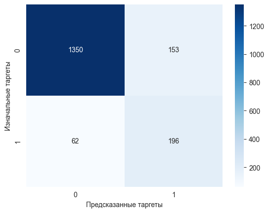

```python
sns.heatmap(cm, annot=True, cmap='Blues', fmt='g')
plt.xlabel('Предсказанные таргеты')
plt.ylabel('Изначальные таргеты')
plt.show()
```

### Итог

В целом, проект успешно продемонстрировал эффективность машинного обучения в прогнозировании оттока клиентов и то, как оно может помочь бизнесу принимать обоснованные решения. Полученные в ходе проекта выводы могут быть использованы компанией для улучшения стратегии удержания клиентов и минимизации их оттока.